# Linear Regression

Everything You Need to Know

Nick Broussard

04 February 2020

## Hello!!

Welcome to this tutorial on multiple linear regression!

Linear regression is statistical tool used to test hypothesis about the influence of certain variables (predictors) on another (outcome). The null hypothesis states that variables *do not* affect on each other, wheareas the alternate hypothesis states that the variables *do* affect each other.

$\ h_{0}$: Variables do not affect each other $\ h_{a}$: Variables do affect each other

If we get significant model predictors then we’ll reject the null hypothesis. Otherwise, we fail to reject the null hypothesis. Significance means that a given effect is **super rare** - *so rare* in fact that its highly unlikely we’d see that effect if it wasn’t real.

Data comes from the City of Austin’s [Open Data Portal](https://data.austintexas.gov/). We’re looking at Energy Conservation Audit and Disclosure [(ECAD)](https://austinenergy.com/ae/energy-efficiency/ecad-ordinance/for-multifamily-properties) data [(found here)]([here](https://data.austintexas.gov/Utilities-and-City-Services/2009-2013-ECAD-Residential-Energy-Audit-Data/me4f-48mc). I want to examine how average monthly energy use in kWh is effected by a multifamily residential building’s year of construction, size in sft, attic insulation (R-value), and number of floors.

## Expore and Clean

First, read in the dataset.

```r
#Download from my GitHub folder.
df <- fread("https://raw.githubusercontent.com/nicholasbroussard/tutorials/master/linear.multiple_ecad_austin.csv", stringsAsFactors = F)
```

Second, select the variables of interest and rename.

```r
df <- df %>%
  select("Average Monthly kWh", "ECAD Year Built", "Average Apt Size", "ECAD R Value", "ECAD Number of Floors") %>%
  #Let's the variables easier-to-read names.
  setnames(old = c("Average Monthly kWh", "ECAD Year Built", "Average Apt Size", "ECAD R Value", "ECAD Number of Floors"),
           new = c("Energy",  "YearBuilt", "Size", "RValue", "Floors"))
```

Third, check variable types…

```r
str(df)
```

Classes ‘data.table’ and ‘data.frame’: 1495 obs. of 5 variables: $ Energy : int 470 162 454 525 516 488 518 448 542 460 … $ YearBuilt: chr “1960” “1964” “1966” “1946” … $ Size : num 709 742 770 786 674 … $ RValue : num 20 2 2 NA 1 30 1 NA 1 30 … $ Floors : int 2 2 3 2 3 2 2 NA 3 2 … - attr(*, “.internal.selfref”)=

…and convert as needed.

```r
df$YearBuilt <- as.numeric(as.character(df$YearBuilt))
df$Floors <- as.factor(as.numeric(df$Floors))
```

Fourth, inspect the categorical.

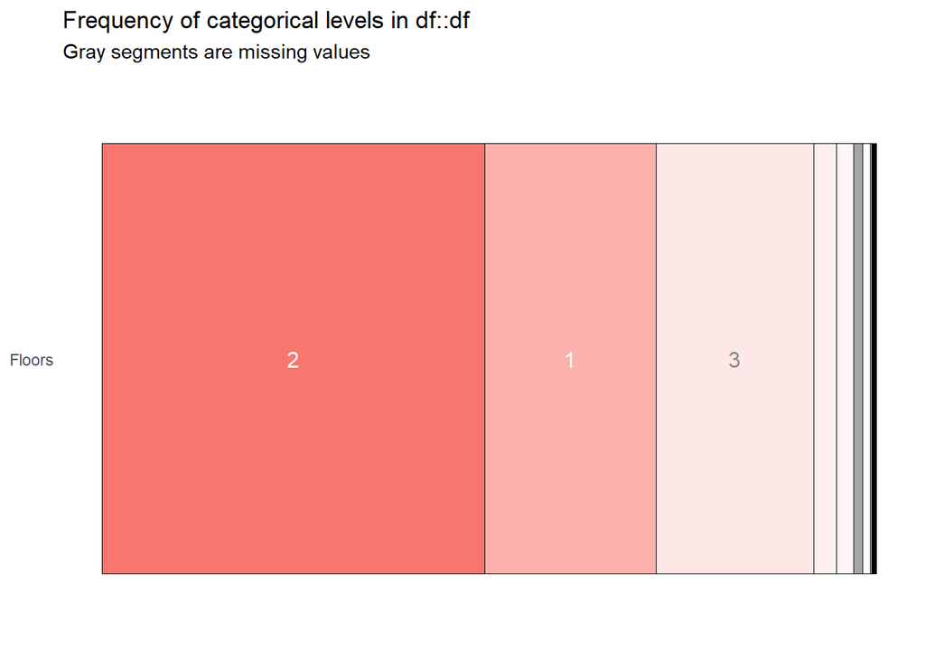

```r
df %>%
  inspect_cat() %>%
  show_plot()
```

Based on this distribution…

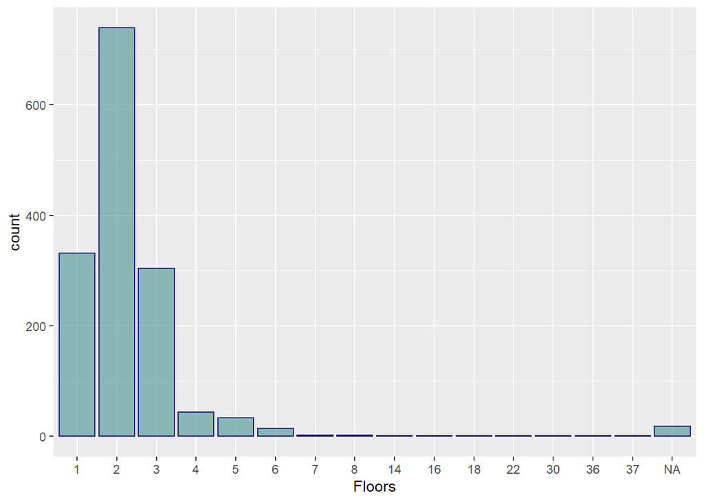

```r
ggplot(df, aes(x = Floors)) +
  geom_bar(color = "midnightblue", fill = "cadetblue", alpha = .7)
```

…restrict.

```r
df <- df %>%
  filter(Floors == "1" | Floors == "2" | Floors == "3" |  is.na(Floors))
```

Fifth, inspect numerics by calling the 5-number-summary…

```r
df %>%
  descr(transpose = T,
       stats = "fivenum") %>%
  print(headings = F,
        method = "render")
```

|  | Min | Q1 | Median | Q3 | Max |
| --- | --- | --- | --- | --- | --- |
| **Energy** | 0.00 | 420.00 | 551.00 | 700.00 | 1513.00 |
| **RValue** | 1.00 | 1.00 | 12.00 | 19.00 | 42.00 |
| **Size** | 168.89 | 572.00 | 720.25 | 866.40 | 1870.36 |
| **YearBuilt** | 0.00 | 1969.00 | 1974.00 | 1988.00 | 2019.00 |

…and histogram distributions for uniformity…

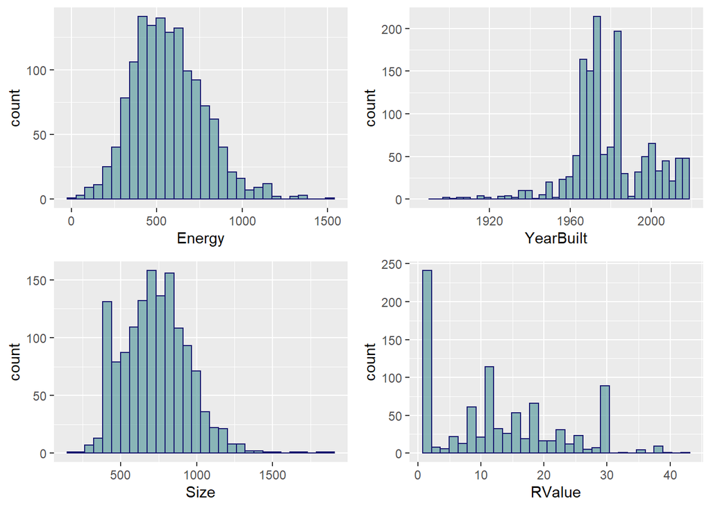

```r
a <- ggplot(df, aes(Energy)) +
  geom_histogram(color = "midnightblue", fill = "cadetblue", alpha = .7, bins = 30)

b <- ggplot(df, aes(YearBuilt)) +
  geom_histogram(color = "midnightblue", fill = "cadetblue", alpha = .7, bins = 40) +
  scale_x_continuous(limits = c(1887, 2019))

c <- ggplot(df, aes(Size)) +
  geom_histogram(color = "midnightblue", fill = "cadetblue", alpha = .7, bins = 30)

d <- ggplot(df, aes(RValue)) +
  geom_histogram(color = "midnightblue", fill = "cadetblue", alpha = .7, bins = 30)

gridExtra::grid.arrange(a,b,c,d)
```

…and for outliers (any value > 1.5*IQR)…

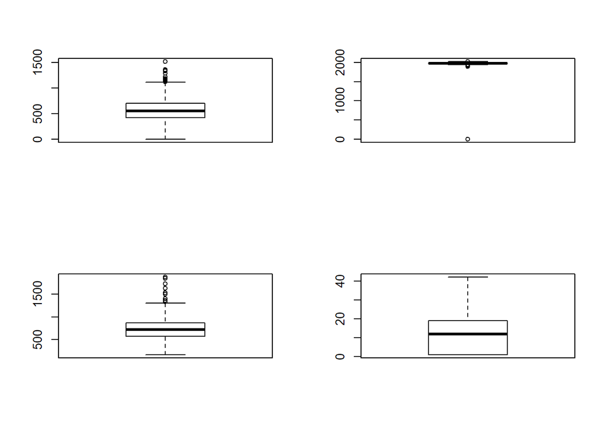

```r
par(mfrow = c(2,2))
energy_outliers <- boxplot(df$Energy)$out
yearbuilt_outliers <- boxplot(df$YearBuilt)$out
size_outliers <- boxplot(df$Size)$out
rvalue_outliers <- boxplot(df$RValue)$out
```

…and reclassify outliers as NAs.

```r
df[which(df$Energy %in% energy_outliers),] <- NA
df[which(df$YearBuilt %in% yearbuilt_outliers),] <- NA
df[which(df$Size %in% size_outliers),] <- NA
df[which(df$RValue %in% rvalue_outliers),] <- NA
```

Sixth, check missingness.

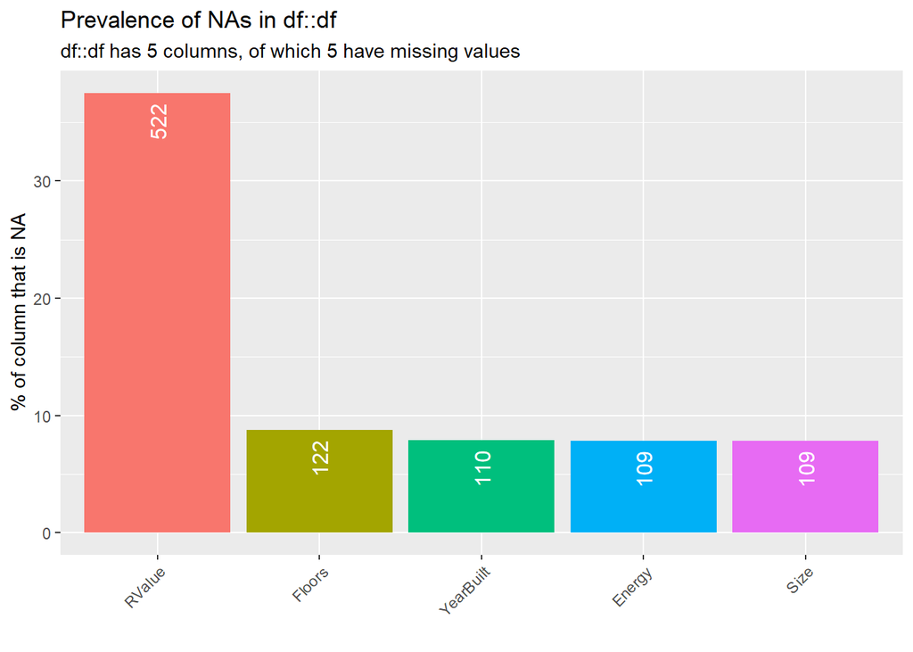

```r
df %>%
  inspect_na() %>%
  show_plot()
```

```r
set.seed(101)
imp <- mice(df, m = 1, maxit = 1, print = F)
df <- complete(imp)
```

Seventh, check correlation.

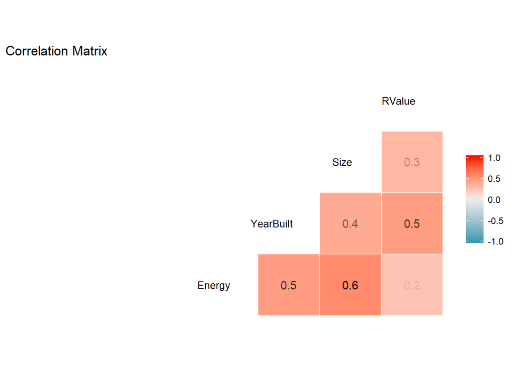

```r
df %>%
  ggcorr(label = TRUE,
         label_alpha = TRUE,
         hjust=.9,
         size=3.5,
         layout.exp=3,
         method = c("pairwise.complete.obs", "spearman")) +
  labs(title="Correlation Matrix")
```

No correlation is above 70%, so no multicolinearity. Read more [here](https://statisticsbyjim.com/regression/multicollinearity-in-regression-analysis/).

Eighth, and finally, analyze variance.

```r
df %>%
  summarise(Energy = var(Energy), YearBuilt = var(YearBuilt), Size = var(Size), RValue = var(RValue))
```

| Energy | YearBuilt | Size | RValue |
| --- | --- | --- | --- |
| 3.68e+04 | 245 | 3.97e+04 | 101 |

Lot’s of variance, which violates the assumption of homoscedasticity. Read more [here](http://davidmlane.com/hyperstat/A121947.html).

Scale variables in the model.

## Model

First, split the data.

```r
set.seed(101)
sample <- sample.split(df, SplitRatio = .7)
train <- subset(df, sample == T)
test <- subset(df, sample == F)
```

Some folks disagree with data-splitting. Check out [this Quora thread](https://www.quora.com/In-machine-learning-what-s-the-purpose-of-splitting-data-up-into-test-sets-and-training-sets) for more info.

Second, run and interpret the regression.

```r
set.seed(101)
model <- lm(Energy ~ ., data = train)
summ(model,
     confint = T,
     scale = T,
     vifs = T) #Variable Inflation Factors
```

| Observations | 836 |
| --- | --- |
| Dependent variable | Energy |
| Type | OLS linear regression |

| F(5,830) | 85.35 |
| --- | --- |
| R² | 0.34 |
| Adj. R² | 0.34 |

|  | Est. | 2.5% | 97.5% | t val. | p | VIF |
| --- | --- | --- | --- | --- | --- | --- |
| (Intercept) | 565.10 | 542.11 | 588.10 | 48.23 | 0.00 | NA |
| YearBuilt | 31.65 | 17.57 | 45.72 | 4.41 | 0.00 | 1.76 |
| Size | 90.12 | 78.09 | 102.14 | 14.71 | 0.00 | 1.28 |
| RValue | 2.22 | -9.89 | 14.33 | 0.36 | 0.72 | 1.30 |
| Floors2 | -3.59 | -32.44 | 25.26 | -0.24 | 0.81 | 1.32 |
| Floors3 | 28.20 | -3.63 | 60.02 | 1.74 | 0.08 | 1.32 |

Standard errors: OLS; Continuous predictors are mean-centered and scaled by 1 s.d.

Third, conduct graphical analysis. Analyze the coefficient effects…

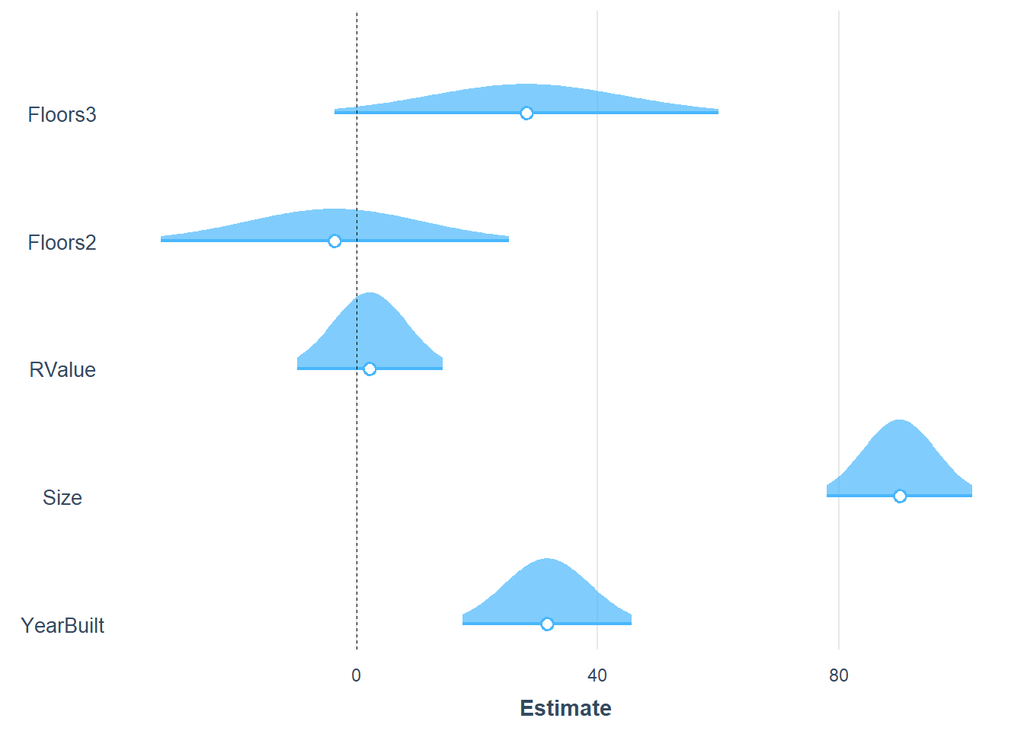

```r
plot_summs(model, plot.distributions = T, scale = T)
```

…then visualize the relationship between each predictor and the dependent variable…

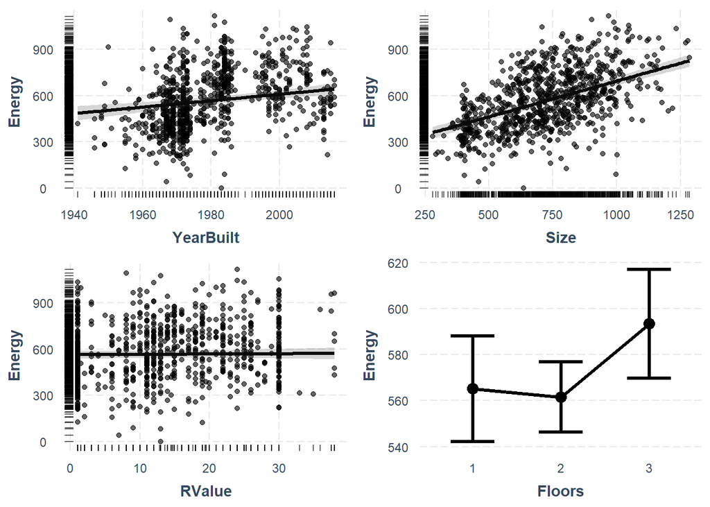

```r
aa <- effect_plot(model, pred = YearBuilt, interval = T, plot.points = T, rug = T)
bb <- effect_plot(model, pred = Size, interval = T, plot.points = T, rug = T)
cc <- effect_plot(model, pred = RValue, interval = T, plot.points = T, rug = T)
dd <- effect_plot(model, pred = Floors, interval = T, cat.geom = "line") #Categorical predictor
gridExtra::grid.arrange(aa,bb,cc,dd)
```

…and look at influential values.

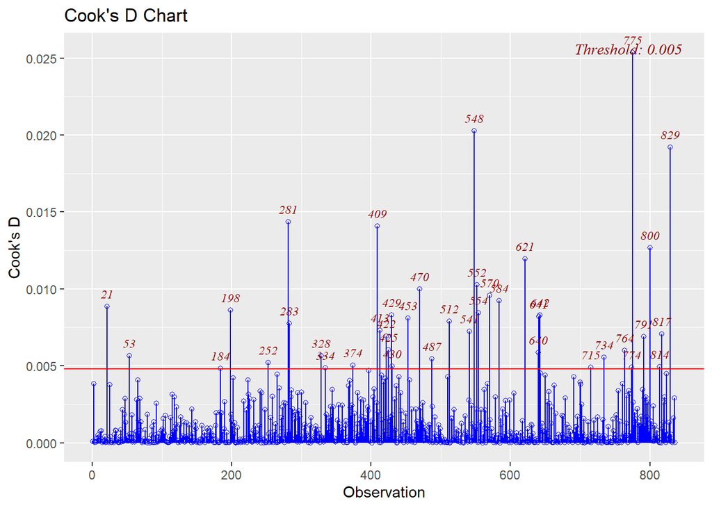

```r
ols_plot_cooksd_chart(model)
```

Examine influential rows individually and remove as needed.

```r
cooksd <- cooks.distance(model)
influential <- as.numeric(names(cooksd))[(cooksd > 4*mean(cooksd, na.rm = T))]
head(train[influential, ], 10)
```

| Energy | YearBuilt | Size | RValue | Floors |
| --- | --- | --- | --- | --- |
| 639 | 1.97e+03 | 956 | 1 | 3 |
| 843 | 2e+03 | 1.28e+03 | 1 | 2 |
| 637 | 1.97e+03 | 732 | 10 | 1 |
| 266 | 1.99e+03 | 842 | 8 | 2 |
| 694 | 1.98e+03 | 652 | 18 | 1 |
| 480 | 2.01e+03 | 761 | 22 | 2 |
| 354 | 1.97e+03 | 611 | 5 | 2 |
| 666 | 1.98e+03 | 691 | 12 | 2 |
| 782 | 1.99e+03 | 710 | 11 | 2 |
| 514 | 1.96e+03 | 554 | 13 | 2 |

Fourth, pull in fitted and residual values…

```r
train$Residuals <- model$residuals
train$Fitted <- model$fitted.values
```

…and query the model.

- What’s predicted energy use for homes built in 1981?

  | YearBuilt | mean(Fitted) |
  | --- | --- |
  | 1.98e+03 | 558 |

  kWh/month.
- What’s the predicted energy use of a 2nd floor unit larger than 600 sft?

  | mean(Fitted) |
  | --- |
  | 580 |

  kWh/month

*But*… answers are only as reliable as the model.

Fifth, evaluate goodness of fit.

Start with the baseline metrics…

- R Squared: 34%
- Adjusted R Squared: 34%
- Root Mean Squared Error (RMSE): 156

…then look at residuals. Check for normality…

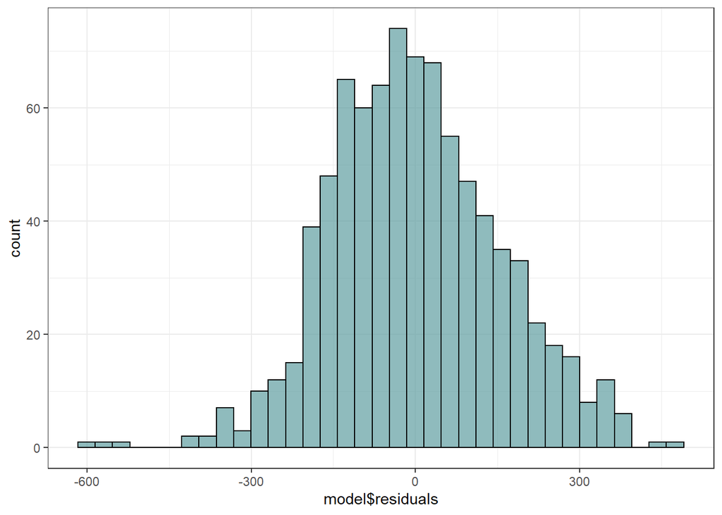

```r
ggplot(train, aes(x = model$residuals)) +
  geom_histogram(bins = 35, color = "black", fill = "cadetblue", alpha = .7) +
  theme_bw()
```

…and the scatter of residuals against predictions.

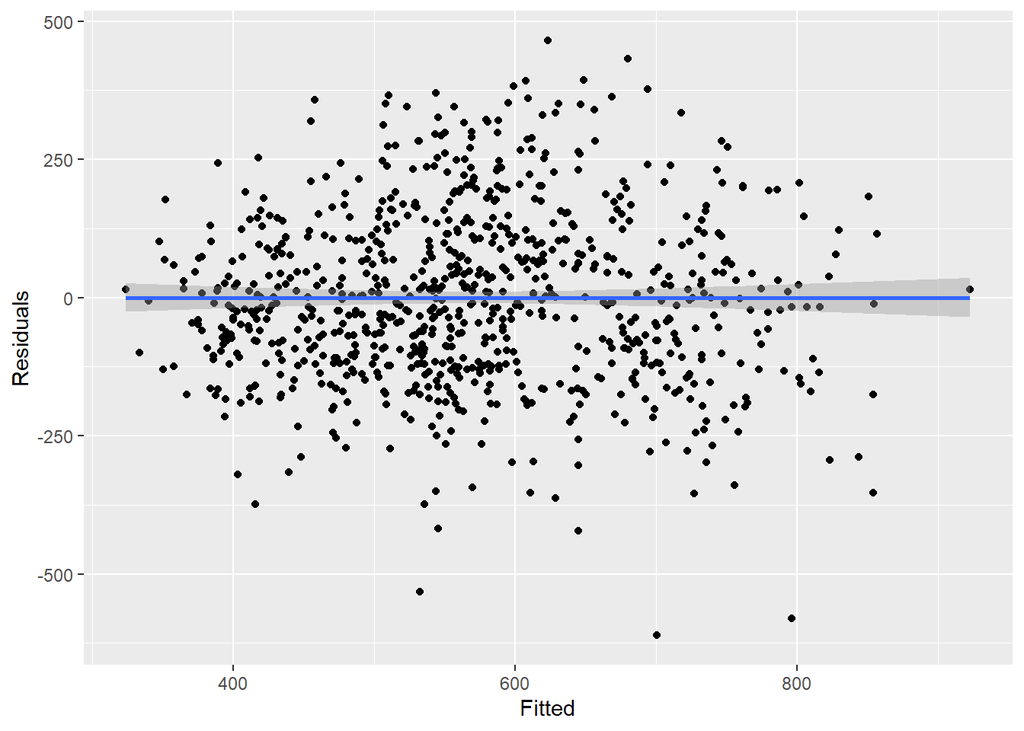

```r
ggplot(train, aes(x=Fitted, y=Residuals)) +
  geom_point() +
  geom_smooth(method = "lm")
```

The distribution shows (1) centering on 0, and (2) a [“degree of scattering [that] is the same for all fitted values”](https://statisticsbyjim.com/regression/check-residual-plots-regression-analysis/). Therefore there’s no indication of autocorrelation.

Sixth, and last, check the model’s performance with test data. Compare RMSEs.

```r
test$Fitted <- predict(model, newdata = test)
df %>%
  summarise("Train Set RMSE" = round(rmse(train$Energy, train$Fitted), digits = 2), "Test Set RMSE" = round(rmse(test$Energy, test$Fitted), digits=2))
```

| Train Set RMSE | Test Set RMSE |
| --- | --- |
| 156 | 157 |

The train RMSE is lower the test RMSE. No indication of overfitting.

## Compare

Run an interactive model to compare against the first model.

First, graphically analyze the effects of predictor varibales on each other. Here, we focus on Size.

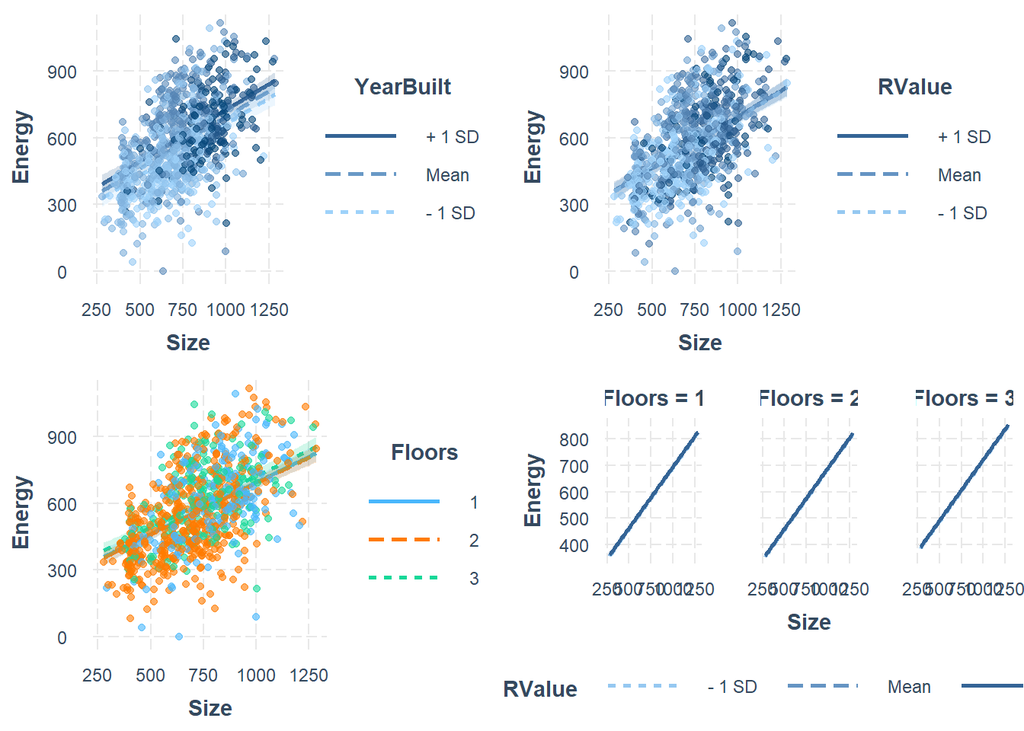

```r
a <- interact_plot(model, pred = Size, modx = YearBuilt, plot.points = T, interval = T)
b <- interact_plot(model, pred = Size, modx = RValue, plot.points = T, interval = T)
c <- interact_plot(model, pred = Size, modx = Floors, plot.points = T, interval = T) #Categorical variable.
d <- interact_plot(model, pred = Size, modx = RValue, mod2 = Floors) #3-way interaction.

gridExtra::grid.arrange(a,b,c,d)
```

[“Parallel lines indicate that there is no interaction effect while different slopes suggest that one might be present.”](https://statisticsbyjim.com/regression/interaction-effects/)

Second, run and interpret a model to test the graphical output.

```r
set.seed(101)
model2 <- lm(Energy ~ YearBuilt + Size + RValue + Floors + Size:YearBuilt, data = train)
summ(model2, scale = T, confint = T, digits = 2, vifs = T)
```

| Observations | 836 |
| --- | --- |
| Dependent variable | Energy |
| Type | OLS linear regression |

| F(6,829) | 73.53 |
| --- | --- |
| R² | 0.35 |
| Adj. R² | 0.34 |

|  | Est. | 2.5% | 97.5% | t val. | p | VIF |
| --- | --- | --- | --- | --- | --- | --- |
| (Intercept) | 575.09 | 551.38 | 598.80 | 47.61 | 0.00 | NA |
| YearBuilt | 39.33 | 24.53 | 54.13 | 5.22 | 0.00 | 1.97 |
| Size | 90.51 | 78.54 | 102.47 | 14.85 | 0.00 | 1.28 |
| RValue | 0.73 | -11.35 | 12.81 | 0.12 | 0.91 | 1.31 |
| Floors2 | -5.48 | -34.20 | 23.24 | -0.37 | 0.71 | 1.33 |
| Floors3 | 23.51 | -8.28 | 55.29 | 1.45 | 0.15 | 1.33 |
| YearBuilt:Size | -17.77 | -28.87 | -6.67 | -3.14 | 0.00 | 1.19 |

Standard errors: OLS; Continuous predictors are mean-centered and scaled by 1 s.d.

The coefficients of the individual predictors are called “main effects.” For interaction models, ["a significant interaction term means uncertainty about the relative importance of main effects.](https://stattrek.com/multiple-regression/interaction.aspx)

Third, compare the new model to the original by coefficients…

```r
export_summs(model, model2,
             scale = T,
             error_format = "[{conf.low},{conf.high}]") #Include confidence intervals for each variable.
```

|  | Model 1 | Model 2 |
| --- | --- | --- |
| (Intercept) | 565.10 *** | 575.09 *** |
|  | [542.11,588.10] | [551.38,598.80] |
| YearBuilt | 31.65 *** | 39.33 *** |
|  | [17.57,45.72] | [24.53,54.13] |
| Size | 90.12 *** | 90.51 *** |
|  | [78.09,102.14] | [78.54,102.47] |
| RValue | 2.22 | 0.73 |
|  | [-9.89,14.33] | [-11.35,12.81] |
| Floors2 | -3.59 | -5.48 |
|  | [-32.44,25.26] | [-34.20,23.24] |
| Floors3 | 28.20 | 23.51 |
|  | [-3.63,60.02] | [-8.28,55.29] |
| YearBuilt:Size |  | -17.77 ** |
|  |  | [-28.87,-6.67] |
| N | 836 | 836 |
| R2 | 0.34 | 0.35 |
| *** p < 0.001; ** p < 0.01; * p < 0.05. |  |  |

…and graphically.

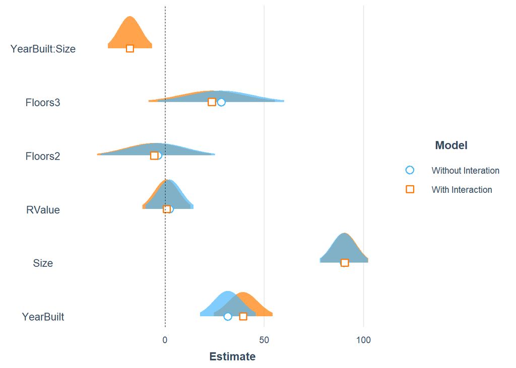

```r
plot_summs(model, model2, scale = T, plot.distributions = T, model.names = c("Without Interation", "With Interaction"))
```

Stick with the first model, even with the low goodness of fit measures. For now.

## Sources

I heavily relied on the following online blogs and tutorials:

- Tools for Summarizing and Vizualising Regression Models: https://cran.r-project.org/web/packages/jtools/vignettes/summ.html
- Removing Outliers: https://rpubs.com/Mentors_Ubiqum/removing_outliers
- Cook’s D: https://cran.r-project.org/web/packages/olsrr/vignettes/influence_measures.html
- Outlier Treatment: http://r-statistics.co/Outlier-Treatment-With-R.html
- Visualizing Residuals: https://drsimonj.svbtle.com/visualising-residuals
- Visualizing Predictions: https://cran.r-project.org/web/packages/jtools/vignettes/effect_plot.html
- Interactions with Continuous Predictors: https://cran.r-project.org/web/packages/interactions/vignettes/interactions.html
- Interactions with Categorical Predictors: https://cran.r-project.org/web/packages/interactions/vignettes/categorical.html
- DataCamp’s LR Tutorial: https://www.datacamp.com/community/tutorials/linear-regression-R
- Another Tutorial: http://r-statistics.co/Linear-Regression.html
- Interpreting Interactions in Regression: https://www.theanalysisfactor.com/interpreting-interactions-in-regression/